# Factors related to lead testing in Philadelphia

Using Philadelphia open data

Alice Walsh

1/28/2018

# Overview

This document is an example analysis using data found on www.opendataphilly.org

It was prepared for R-Ladies Philly.

# Data sources

## Lead testing data

Data about lead testing in children by zip code was loaded from https://phl.carto.com/api/v2/sql?q=SELECT+*+FROM+child_blood_lead_levels_by_zip&filename=child_blood_lead_levels_by_zip&format=csv&skipfields=cartodb_id,the_geom,the_geom_webmercator.  
More information on this data can be found at: https://www.opendataphilly.org/dataset/philadelphia-child-blood-lead-levels

```r
lead_data <- read.csv(lead_source)

knitr::kable(head(lead_data), caption = "First few rows of data")
```

First few rows of data

| zip_code | data_redacted | num_bll_5plus | num_screen | perc_5plus |
| --- | --- | --- | --- | --- |
| 19102 | true | NA | 51 | NA |
| 19103 | true | NA | 224 | NA |
| 19107 | true | NA | 139 | NA |
| 19104 | false | 28 | 805 | 3.5 |
| 19106 | true | NA | 118 | NA |
| 19111 | false | 33 | 1071 | 3.1 |

The lead testing data consists of *46* rows and *5* columns.

## Home prices

Zillow makes home prices and other data available on their website: https://www.zillow.com/research/data/

We loaded the data on median listing prices for all Philadelphia zip codes from: http://files.zillowstatic.com/research/public/Zip/Zip_MedianListingPrice_AllHomes.csv

```r
zillow_data <- read.csv(zillow_source)

knitr::kable(head(zillow_data[,1:7]), caption = "First few rows and columns of data")
```

First few rows and columns of data

| RegionName | City | State | Metro | CountyName | SizeRank | X2010.01 |
| --- | --- | --- | --- | --- | --- | --- |
| 10025 | New York | NY | New York | New York | 1 | 775000 |
| 60657 | Chicago | IL | Chicago | Cook | 2 | 349900 |
| 10023 | New York | NY | New York | New York | 3 | NA |
| 77494 | Cinco Ranch | TX | Houston | Fort Bend | 4 | 285000 |
| 75070 | McKinney | TX | Dallas-Fort Worth | Collin | 5 | 191315 |
| 60614 | Chicago | IL | Chicago | Cook | 6 | NA |

The data contains data from all over the country, we will only keep the Philadelphia data. The columns contain median home prices for a given year and month.

The two datasets were merged - this will only select rows with zip codes in common between the two datasets.

```r
full_dataset <- merge(lead_data, zillow_data, by.x = "zip_code", by.y = "RegionName")
```

The merged data consists of *37* rows and *106* columns.

# Visualization

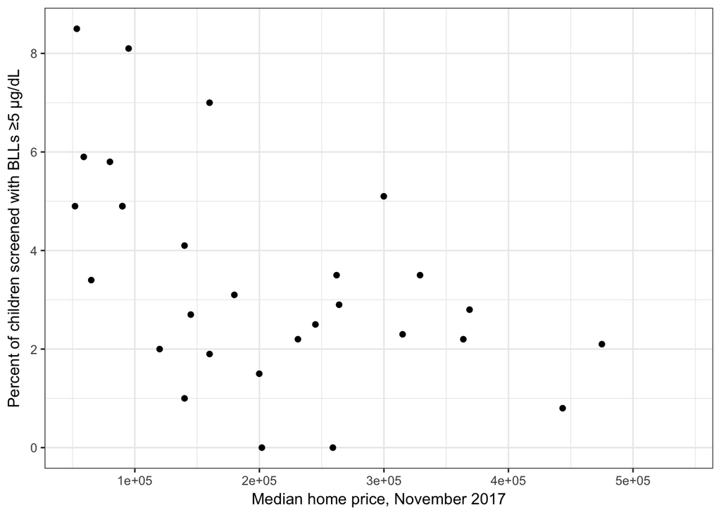

```r
ggplot(full_dataset, aes(x = X2017.11, y = perc_5plus)) +
  geom_point() +
  ylab("Percent of children screened with BLLs ≥5 µg/dL") +
  xlab("Median home price, November 2017") +
  theme_bw()
```

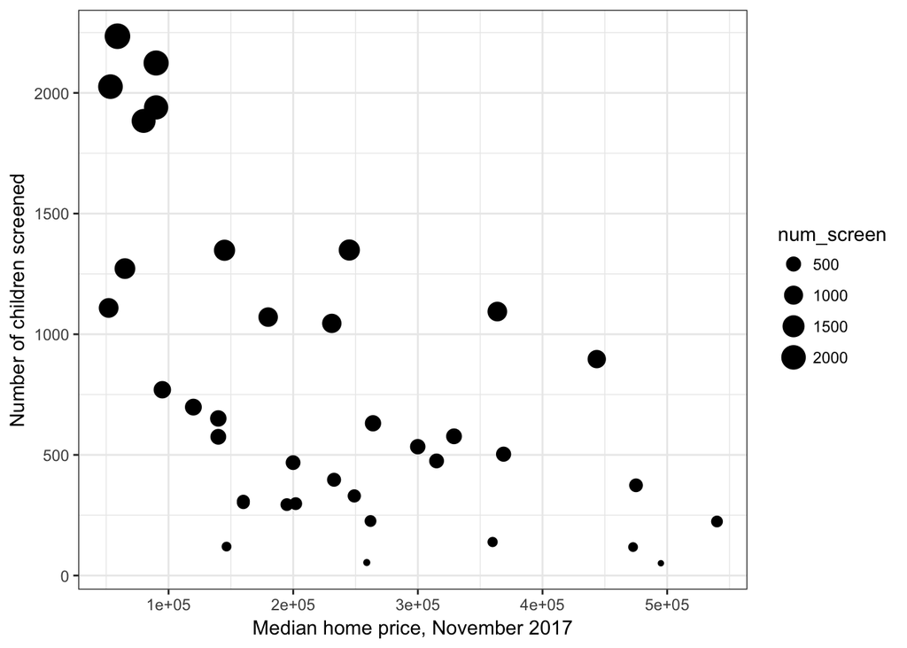

```r
ggplot(full_dataset, aes(x = X2017.11, y = num_screen)) +
  geom_point(aes(size=num_screen)) +
  ylab("Number of children screened") +
  xlab("Median home price, November 2017") +
  theme_bw()
```

It looks like lead testing and positive lead tests are higher in zip codes with lower home values.

# Future directions

The plots above are fairly boring. We could add some categories to facet by or color by.  
For example:

- Binning home prices to create categories
- Adding in meta-data from other sources, such as the total population of each zip code
- Adding any factors that might differentiate zip codes with similar lead levels
- Performing statistical tests

# Contact information

For any questions, contact philly@rladies.org